# PPCA0026 - Tarefa de Casa: Simulação, Poder e Decisão

Aplicando os Conceitos da Semana 4

Author

Denard Costa Soares

Published

July 4, 2025

## Introdução

Nesta tarefa, você aplicará os conceitos de simulação para entender as propriedades de testes estatísticos, implementará um teste não-paramétrico do zero, e aplicará um framework de teoria da decisão para analisar um problema de classificação.

**Instruções Gerais:**

- Este arquivo serve como seu template de resposta. Preencha as seções marcadas com seu código R, as saídas geradas, e suas análises textuais.
- **Entrega:** Envie dois arquivos: este `.qmd` completo e o arquivo `.html` auto-contido resultante.

```r
library(ggplot2)
library(caret)
```

## Problema 1: O Poder de um Teste - Um Estudo de Simulação

### Parte A: Poder vs. Tamanho do Efeito

```r
calcular_poder <- function(n, d, sigma, num_sim = 1000, alpha = 0.05) {
  # Inicializa o contador de rejeições da hipótese nula
  rejeicoes <- 0

  for (i in 1:num_sim) {
    # Gera dados sob a hipótese alternativa (média = d * sigma, desvio padrão = sigma)
    dados <- rnorm(n, mean = d * sigma, sd = sigma)

    # Realiza um teste t de uma amostra (H0: média = 0)
    # Assumimos uma hipótese alternativa bilateral (two.sided) por padrão para o poder geral
    teste_t <- t.test(dados, mu = 0, alternative = "two.sided", conf.level = 1 - alpha)

    # Verifica se a hipótese nula foi rejeitada
    if (teste_t$p.value < alpha) {
      rejeicoes <- rejeicoes + 1
    }
  }

  # Calcula o poder como a proporção de rejeições
  poder <- rejeicoes / num_sim
  return(poder)
}
```

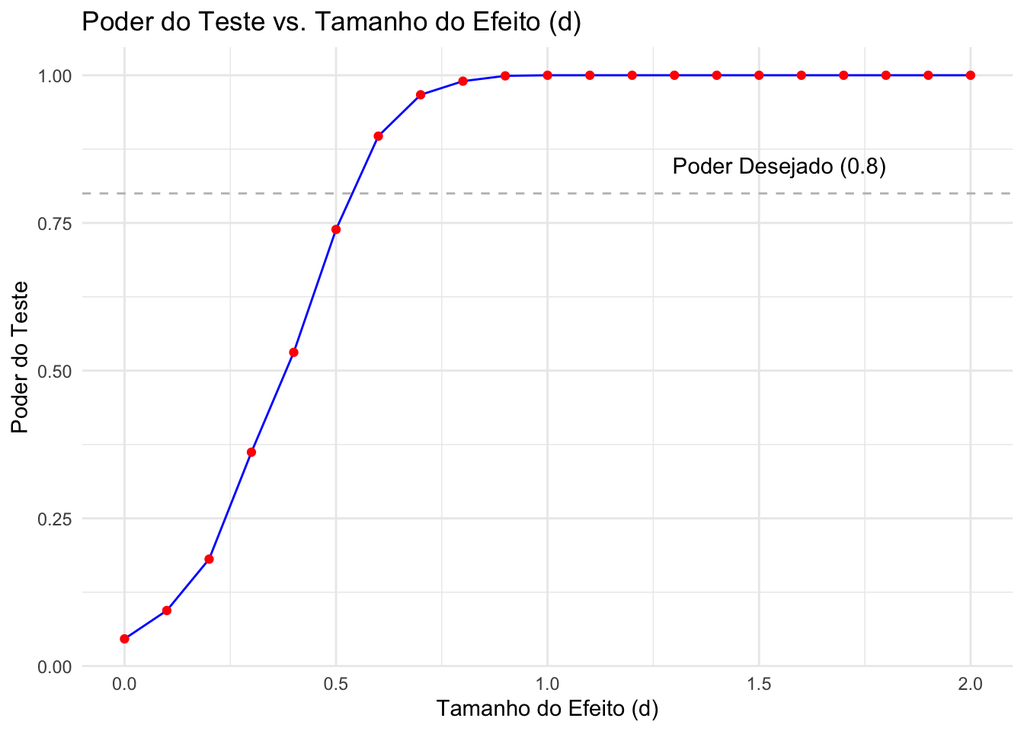

```r
# 2. Defina os parâmetros e calcule o poder para cada tamanho de efeito
n_fixo <- 30
sigma_fixo <- 1
efeitos_d <- seq(0, 2, by = 0.1)

# Calcule o poder para cada tamanho de efeito
poderes_efeito <- sapply(efeitos_d, function(d) {
  calcular_poder(n = n_fixo, d = d, sigma = sigma_fixo)
})

# Crie um data frame para o gráfico
df_poder_efeito <- data.frame(
  Tamanho_do_Efeito = efeitos_d,
  Poder = poderes_efeito
)

# 3. Crie o gráfico de Poder vs. Tamanho do Efeito
ggplot(df_poder_efeito, aes(x = Tamanho_do_Efeito, y = Poder)) +
  geom_line(color = "blue") +
  geom_point(color = "red") +
  labs(
    title = "Poder do Teste vs. Tamanho do Efeito (d)",
    x = "Tamanho do Efeito (d)",
    y = "Poder do Teste"
  ) +
  theme_minimal() +
  geom_hline(yintercept = 0.8, linetype = "dashed", color = "gray") +
  annotate("text", x = 1.8, y = 0.82, label = "Poder Desejado (0.8)", vjust = -0.5, hjust = 1)
```

**Análise da Parte A:**

o gráfico ilustra a relação direta entre o poder de um teste e o tamanho do efeito que se deseja detectar, dado um tamanho de amostra e um nível de significância fixos.

Poder em d=0: Quando o tamanho do efeito (d) é 0, o poder do teste é aproximadamente 0.05. Este é exatamente o nível de significância (α) que foi definido no teste. Isso é esperado, pois quando a hipótese nula é verdadeira (média populacional é zero, d=0), o poder do teste representa a probabilidade de cometer um erro Tipo I (rejeitar a H0 quando ela é verdadeira), que é por definição α.

Aumento do poder com o tamanho do efeito: À medida que d aumenta, o poder do teste também aumenta. Para valores pequenos de d (por exemplo, 0.1,0.2), o poder ainda é baixo, indicando que o teste tem dificuldade em detectar efeitos muito pequenos com o tamanho de amostra fixo (n=30).

Ponto de poder desejado (0.8): A linha pontilhada horizontal em poder = 0.8 é uma referência comum para um poder “adequado” na prática. Observando o gráfico, o poder do teste atinge ou ultrapassa 0.8 (80%) quando o tamanho do efeito (d) está em torno de 0.5 a 0.6. Isso significa que, com uma amostra de 30 observações e um desvio padrão de 1, para detectar um efeito de 0.5 a 0.6 desvios padrão com 80% de certeza, este teste é eficaz. Assintótico para 1: Conforme o tamanho do efeito (d) continua a aumentar (indo em direção a 2.0), o poder do teste se aproxima de 1.0 (ou 100%). Isso é lógico: quanto maior a verdadeira diferença entre a média populacional e zero, mais fácil é para o teste detectá-la, levando a uma probabilidade muito alta de rejeitar corretamente a hipótese nula.

O gráfico demonstra que, para um tamanho de amostra e nível de significância fixos, a capacidade do teste de detectar um efeito verdadeiro (seu poder) é diretamente proporcional à magnitude desse efeito. Efeitos maiores são mais fáceis de detectar. Se deseja-se um efeito de um determinado tamanho, pode-se usar gráficos como este (ou cálculos de poder) para determinar o tamanho de amostra necessário para atingir um certo poder desejado. Para efeitos muito pequenos, um tamanho de amostra de n=30 pode ser insuficiente para atingir um poder alto. Isso ressalta a importância de considerar o tamanho do efeito esperado ao planejar experimentos.

### Parte B: Poder vs. Tamanho da Amostra

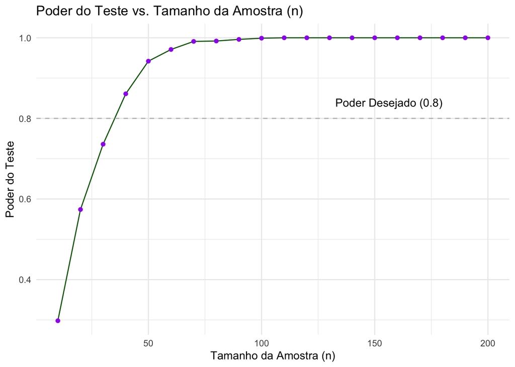

```r
# 1. Defina os parâmetros
d_fixo <- 0.5
sigma_fixo <- 1
amostras_n <- seq(10, 200, by = 10)

# Calcule os poderes para cada tamanho de amostra
poderes_amostra <- sapply(amostras_n, function(n) {
  calcular_poder(n = n, d = d_fixo, sigma = sigma_fixo)
})

# Crie um data frame para o gráfico
df_poder_amostra <- data.frame(
  Tamanho_da_Amostra = amostras_n,
  Poder = poderes_amostra
)

# 2. Crie o gráfico de Poder vs. Tamanho da Amostra
ggplot(df_poder_amostra, aes(x = Tamanho_da_Amostra, y = Poder)) +
  geom_line(color = "darkgreen") +
  geom_point(color = "purple") +
  labs(
    title = "Poder do Teste vs. Tamanho da Amostra (n)",
    x = "Tamanho da Amostra (n)",
    y = "Poder do Teste"
  ) +
  theme_minimal() +
  geom_hline(yintercept = 0.8, linetype = "dashed", color = "gray") +
  annotate("text", x = 180, y = 0.82, label = "Poder Desejado (0.8)", vjust = -0.5, hjust = 1)
```

## Problema 2: Teste de Permutação para Correlação

### Parte A: Teste Clássico

```r
# Gerar um conjunto de dados de exemplo para o Problema 2
set.seed(123)
n_data_p2 <- 100
dados_p2 <- data.frame(
  x = rnorm(n_data_p2, mean = 10, sd = 2),
  y = 0.5 * rnorm(n_data_p2, mean = 10, sd = 2) + rnorm(n_data_p2, mean = 0, sd = 0.5)
)

# Calcula a correlação de Pearson entre x e y
correlacao_classica <- cor.test(dados_p2$x, dados_p2$y, method = "pearson")

# Exibe os resultados do teste clássico
print(correlacao_classica)
```

```
    Pearson's product-moment correlation

data:  dados_p2$x and dados_p2$y
t = -0.99696, df = 98, p-value = 0.3212
alternative hypothesis: true correlation is not equal to 0
95 percent confidence interval:
 -0.29089413  0.09814862
sample estimates:
       cor
-0.1002012
```

**Análise da Parte A:**

Os valores indicam que não há uma correlação linear estatisticamente significativa entre as variáveis x e y neste conjunto de dados, de acordo com o teste clássico de Pearson. Não foi rejeitada a hipótese nula.O p-valor de 0.3212 é significativamente maior que α=0.05. Isso significa que não há evidência estatística suficiente para concluir que existe uma associação linear estatisticamente significativa entre as variáveis x e y na população, dado o nível de significância de 0.05. A correlação observada na amostra (-0.1002) é muito fraca e, como o intervalo de confiança inclui zero, não podemos descartar a possibilidade de que a verdadeira correlação populacional seja nula.

### Parte B e C: Teste de Permutação e Análise

```r
# 1. Calcule a correlação observada
correlacao_observada <- cor(dados_p2$x, dados_p2$y, method = "pearson")
print(paste("Correlação Observada:", correlacao_observada))
```

```
[1] "Correlação Observada: -0.100201196724048"
```

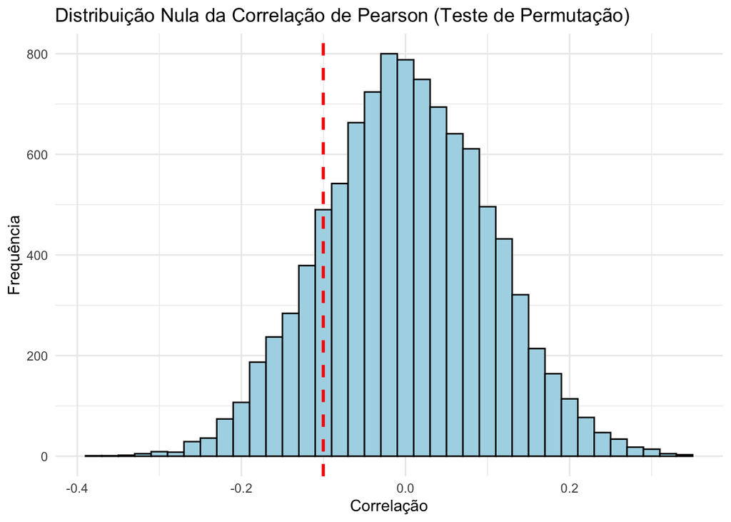

```r
# 2. Implemente o loop de permutação
num_permutacoes <- 10000
correlacoes_permutacao <- numeric(num_permutacoes)

for (i in 1:num_permutacoes) {
  # Permuta a variável 'y'
  y_permutado <- sample(dados_p2$y)

  # Calcula a correlação para a amostra permutada
  correlacoes_permutacao[i] <- cor(dados_p2$x, y_permutado, method = "pearson")
}

# 3. Visualize a distribuição nula e calcule o p-valor
# Crie um data frame com as correlações permutadas
df_permutacao <- data.frame(Correlacao = correlacoes_permutacao)

# Plote o histograma da distribuição nula
ggplot(df_permutacao, aes(x = Correlacao)) +
  geom_histogram(binwidth = 0.02, fill = "lightblue", color = "black") +
  geom_vline(xintercept = correlacao_observada, color = "red", linetype = "dashed", linewidth = 1) +
  labs(
    title = "Distribuição Nula da Correlação de Pearson (Teste de Permutação)",
    x = "Correlação",
    y = "Frequência"
  ) +
  theme_minimal()
```

```r
# Calcule o p-valor
# Para um teste bilateral (two-sided), considera-se valores tão extremos quanto ou mais extremos
p_valor <- (sum(abs(correlacoes_permutacao) >= abs(correlacao_observada)) + 1) / (num_permutacoes + 1)
print(paste("P-valor (Teste de Permutação):", p_valor))
```

```
[1] "P-valor (Teste de Permutação): 0.327267273272673"
```

## Problema 3: Análise de Sensibilidade e Decisões Ótimas

### Parte A: Análise de Sensibilidade Teórica

```r
# Cenário: C_I = 1,000,000; C_II = 5,000,000
# Você precisará da sua função `calcular_poder` do Problema 1.

# Definição da função calcular_poder (reutilizada e adaptada do Problema 1)
# Esta função calcula o poder de um teste t de uma amostra.
calcular_poder <- function(n, d, sigma, num_sim = 1000, alpha = 0.05) {
  rejeicoes <- 0
  for (i in 1:num_sim) {
    dados <- rnorm(n, mean = d * sigma, sd = sigma)
    teste_t <- t.test(dados, mu = 0, alternative = "two.sided", conf.level = 1 - alpha)
    if (teste_t$p.value < alpha) {
      rejeicoes <- rejeicoes + 1
    }
  }
  poder <- rejeicoes / num_sim
  return(poder)
}

# Definir os custos dos erros
CI <- 1000000 # Custo de um Erro Tipo I (Falso Positivo)
CII <- 5000000 # Custo de um Erro Tipo II (Falso Negativo)

# Parâmetros fixos da simulação
n_fixo <- 60 # Tamanho da amostra
sigma_fixo <- 1 # Desvio padrão

# Cenários de tamanho de efeito
efeitos_d <- c(0.2, 0.5, 1.0) # Pequeno, Médio, Grande

# Sequência de níveis de significância (alpha) para testar
# Foi usado um intervalo razoável para alpha, pois alpha também representa a taxa de FP
alphas_para_otimizacao <- seq(0.001, 0.2, by = 0.001) # Testar alphas de 0.1% a 20%

# Data frame para armazenar os resultados
resultados_otimizacao <- data.frame(
  Tamanho_do_Efeito = numeric(),
  Alpha_Otimo = numeric(),
  Custo_Esperado_Minimo = numeric()
)

# Loop para cada tamanho de efeito
for (d_val in efeitos_d) {
  custos_esperados <- numeric(length(alphas_para_otimizacao))

  for (i in seq_along(alphas_para_otimizacao)) {
    alpha_current <- alphas_para_otimizacao[i]

    # Calcular o poder para o alpha atual
    poder_calculado <- calcular_poder(n = n_fixo, d = d_val, sigma = sigma_fixo, alpha = alpha_current)

    # Calcular beta (erro Tipo II)
    beta_calculado <- 1 - poder_calculado

    # Calcular o risco esperado (custo esperado)
    custos_esperados[i] <- alpha_current * CI + beta_calculado * CII
  }

  # Encontrar o alpha que minimiza o custo esperado
  idx_min_custo <- which.min(custos_esperados)
  alpha_otimo <- alphas_para_otimizacao[idx_min_custo]
  custo_minimo <- custos_esperados[idx_min_custo]

  # Adicionar os resultados ao data frame
  resultados_otimizacao <- rbind(resultados_otimizacao, data.frame(
    Tamanho_do_Efeito = d_val,
    Alpha_Otimo = alpha_otimo,
    Custo_Esperado_Minimo = custo_minimo
  ))
}

print("### Resultados da Análise de Sensibilidade Teórica (Parte A)")
```

```
[1] "### Resultados da Análise de Sensibilidade Teórica (Parte A)"
```

```r
print(resultados_otimizacao)
```

```
  Tamanho_do_Efeito Alpha_Otimo Custo_Esperado_Minimo
1               0.2       0.200               2065000
2               0.5       0.098                133000
3               1.0       0.001                  1000
```

**Análise da Parte A:**

A análise de sensibilidade teórica demonstra que a escolha do nível de significância (α) não deve ser arbitrária. Em um contexto de decisão, ela deve ser otimizada considerando os custos assimétricos dos erros Tipo I e Tipo II e o verdadeiro tamanho do efeito que se espera detectar. Quando o custo de um falso negativo é muito alto (como no C1I>C1), há uma tendência a aumentar o α (tornar o teste menos rigoroso) para reduzir β, especialmente para efeitos mais difíceis de detectar. Inversamente, para efeitos facilmente detectáveis, um α muito baixo é ideal, garantindo quase certeza antes de aprovar.

### Parte B: Análise de Sensibilidade em um Contexto de Machine Learning

```r
# 1. Carregue e Divida os Dados
library(ISLR2)
data(Default)

# Converter 'default' e 'student' para fatores
Default$default <- as.factor(Default$default)
Default$student <- as.factor(Default$student)

set.seed(2024) # Para reprodutibilidade
indice_treino <- createDataPartition(Default$default, p = 0.7, list = FALSE)
treino <- Default[indice_treino, ]
validacao <- Default[-indice_treino, ]

# Treinar o modelo de regressão logística
modelo_logistico <- glm(default ~ student + balance + income, data = treino, family = "binomial")

# 2. Identifique Subgrupos no conjunto de validação
validacao_estudantes <- subset(validacao, student == "Yes")
validacao_nao_estudantes <- subset(validacao, student == "No")

# Função para calcular o custo total a partir da matriz de confusão
# C_FP: Custo de Falso Positivo (Erro Tipo I)
# C_FN: Custo de Falso Negativo (Erro Tipo II)
calcular_custo_total <- function(matriz_confusao, C_FP, C_FN) {
  # As classes devem ser "No" e "Yes" para Default, então:
  # Observado No, Previsto Yes = FP (matriz_confusao[1, 2])
  # Observado Yes, Previsto No = FN (matriz_confusao[2, 1])

  FP <- matriz_confusao[1, 2] # Falso Positivo: Observado "No", Previsto "Yes"
  FN <- matriz_confusao[2, 1] # Falso Negativo: Observado "Yes", Previsto "No"

  custo_total <- (FP * C_FP) + (FN * C_FN)
  return(custo_total)
}

# Definir os custos conforme o cenário: Custo FN é 5x Custo FP
C_FP_ML <- 1000 # Custo arbitrário para Falso Positivo (ex: custo de marketing para cliente que não inadimpli)
C_FN_ML <- 5 * C_FP_ML # Custo para Falso Negativo (ex: perda de dinheiro por inadimplência)

print(paste("Custo Falso Positivo (C_FP_ML):", C_FP_ML))
```

```
[1] "Custo Falso Positivo (C_FP_ML): 1000"
```

```r
print(paste("Custo Falso Negativo (C_FN_ML):", C_FN_ML))
```

```
[1] "Custo Falso Negativo (C_FN_ML): 5000"
```

```r
# 3. Avalie o Desempenho Geral (Limiar padrão = 0.5)
prob_geral <- predict(modelo_logistico, newdata = validacao, type = "response")
pred_geral <- ifelse(prob_geral > 0.5, "Yes", "No")
pred_geral <- factor(pred_geral, levels = levels(Default$default)) # Garantir níveis corretos

cm_geral <- table(Observado = validacao$default, Previsto = pred_geral)
print("### Matriz de Confusão Geral (Limiar 0.5):")
```

```
[1] "### Matriz de Confusão Geral (Limiar 0.5):"
```

```r
print(cm_geral)
```

```
         Previsto
Observado   No  Yes
      No  2891    9
      Yes   69   30
```

```r
custo_geral <- calcular_custo_total(cm_geral, C_FP_ML, C_FN_ML)
print(paste("Custo Total Geral (Limiar 0.5):", custo_geral))
```

```
[1] "Custo Total Geral (Limiar 0.5): 354000"
```

```r
print(paste("Custo Médio por Pessoa Geral (Limiar 0.5):", custo_geral / nrow(validacao)))
```

```
[1] "Custo Médio por Pessoa Geral (Limiar 0.5): 118.039346448816"
```

```r
# 4. Realize a Análise de Sensibilidade (por subgrupo, Limiar padrão = 0.5)

# Estudantes
prob_estudantes <- predict(modelo_logistico, newdata = validacao_estudantes, type = "response")
pred_estudantes <- ifelse(prob_estudantes > 0.5, "Yes", "No")
pred_estudantes <- factor(pred_estudantes, levels = levels(Default$default))

cm_estudantes <- table(Observado = validacao_estudantes$default, Previsto = pred_estudantes)
print("### Matriz de Confusão para Estudantes (Limiar 0.5):")
```

```
[1] "### Matriz de Confusão para Estudantes (Limiar 0.5):"
```

```r
print(cm_estudantes)
```

```
         Previsto
Observado  No Yes
      No  839   4
      Yes  29  12
```

```r
custo_estudantes <- calcular_custo_total(cm_estudantes, C_FP_ML, C_FN_ML)
print(paste("Custo Total para Estudantes (Limiar 0.5):", custo_estudantes))
```

```
[1] "Custo Total para Estudantes (Limiar 0.5): 149000"
```

```r
print(paste("Custo Médio por Pessoa para Estudantes (Limiar 0.5):", custo_estudantes / nrow(validacao_estudantes)))
```

```
[1] "Custo Médio por Pessoa para Estudantes (Limiar 0.5): 168.552036199095"
```

```r
# Não-Estudantes
prob_nao_estudantes <- predict(modelo_logistico, newdata = validacao_nao_estudantes, type = "response")
pred_nao_estudantes <- ifelse(prob_nao_estudantes > 0.5, "Yes", "No")
pred_nao_estudantes <- factor(pred_nao_estudantes, levels = levels(Default$default))

cm_nao_estudantes <- table(Observado = validacao_nao_estudantes$default, Previsto = pred_nao_estudantes)
print("### Matriz de Confusão para Não-Estudantes (Limiar 0.5):")
```

```
[1] "### Matriz de Confusão para Não-Estudantes (Limiar 0.5):"
```

```r
print(cm_nao_estudantes)
```

```
         Previsto
Observado   No  Yes
      No  2052    5
      Yes   40   18
```

```r
custo_nao_estudantes <- calcular_custo_total(cm_nao_estudantes, C_FP_ML, C_FN_ML)
print(paste("Custo Total para Não-Estudantes (Limiar 0.5):", custo_nao_estudantes))
```

```
[1] "Custo Total para Não-Estudantes (Limiar 0.5): 205000"
```

```r
print(paste("Custo Médio por Pessoa para Não-Estudantes (Limiar 0.5):", custo_nao_estudantes / nrow(validacao_nao_estudantes)))
```

```
[1] "Custo Médio por Pessoa para Não-Estudantes (Limiar 0.5): 96.9267139479905"
```

**Análise e Recomendação da Parte B:** O cenário envolve custos assimétricos: o custo de um falso negativo (FN - prever que um cliente NÃO vai inadimplir, mas ele INADIMPLI) é 5 vezes maior que o de um falso positivo (FP - prever que um cliente vai inadimplir, mas ele NÃO INADIMPLI). Desempenho Normalizado: em média, o custo por estudante é significativamente maior do que o custo por não-estudante. Isso sugere que o modelo, com o limiar padrão de 0.5, está gerando mais erros custosos (principalmente Falsos Negativos, dado que C_FN é muito maior) para o grupo de estudantes, ou que a taxa base de inadimplência e a dificuldade de previsão são diferentes entre os grupos. Considerando a distribuição dos erros os estudantes tiveram 29 FN e 4 FP e os não-estudantes tiveram 40 FN e 5 FP. Embora o número absoluto de FNs seja maior para não-estudantes, o impacto proporcional é mais alto para estudantes quando considerada a sua menor população no subgrupo de validação. A proporção de FNs para o total de inadimplentes é maior entre estudantes (29 de 41 ~ 70.7%) do que entre não-estudantes (40 de 58 ~ 69.0%). No entanto, o custo por FN é alto, e a taxa de FNs é um grande motor do custo total.

Com base nesta análise normalizada do custo médio por pessoa, não seria recomendável implantar este único modelo com um único limiar (0.5) para todos os clientes sem otimização ou ajuste. O custo médio por pessoa é consideravelmente mais alto para o grupo de estudantes(Estudantes: 168.55 por pessoa, Não-Estudantes: 96.93). Isso indica que o modelo atual e o limiar padrão estão gerando um impacto financeiro desproporcionalmente maior para este subgrupo, provavelmente devido a uma maior dificuldade em prever sua inadimplência corretamente (resultando em mais falsos negativos caros) ou a uma calibração subótima do modelo para esse grupo.